# Project: Darwin's_Finch_Beaks_Evolution_AB*Testing*&_Regression

- Introduction
- Questions
- Data Wrangling
- Exploratory Data Analysis
- AB Testing
- Regression Analysis
- Conclusions

## Introduction

> **Descriptions:** Every year for the past 40-plus years, Peter and Rosemary Grant have gone to the Galápagos island of Daphne Major and collected data on Darwin's finches.We will use this data to study how the beak depth (the distance, top to bottom, of a closed beak) of the finch species Geospiza scandens has changed over time. The Grants have noticed some changes of beak geometry depending on the types of seeds available on the island, and they also noticed that there was some interbreeding with another major species on Daphne Major, Geospiza fortis. These effects can lead to changes in the species over time.In this project we are going to look at the beak depth of G. scandens on Daphne Major in 1975 and in 2012.

**Finch_beaks dataset columns descriptions:**

- **band**: Index.
- **species**: Finches species (fortis, scandens).
- **Beak_length**: Finches beak length.
- **Beak_depth**: Finches beak depth.

## **Questions:**

**1. Has Finches beaks average length been evolved from 1975 to 2012?**

**2. Has Finches beaks average depth been evolved from 1975 to 2012?**

**3. Is there any correlation between Finches beaks length and beak length?**

```python
import pandas as pd
import numpy as np
import matplotlib.pyplot as plt
%matplotlib inline
import seaborn as sns
sns.set_style("whitegrid")
import statsmodels.formula.api as smf
```

## Data Wrangling

**This is a three step process:**

- Gathering the data from Dataset and investegate it trying to understand more details about it.
- Assessing data to identify any issues with data types, structure, or quality.
- Cleaning data by changing data types, replacing values, removing unnecessary data and modifying Dataset for easy and fast analysis.

### Gathering Data

```python
# loading CSV files in to 2 Dataframes  //df_1975 and df_2012//

df_1975 = pd.read_csv("finch_beaks_1975.csv")
df_2012 = pd.read_csv("finch_beaks_2012.csv")
```

```python
#checking 5 rows sample from Dataframes

df_1975.head()
```

|  | band | species | Beak length, mm | Beak depth, mm |
| --- | --- | --- | --- | --- |
| 0 | 2 | fortis | 9.4 | 8.0 |
| 1 | 9 | fortis | 9.2 | 8.3 |
| 2 | 12 | fortis | 9.5 | 7.5 |
| 3 | 15 | fortis | 9.5 | 8.0 |
| 4 | 305 | fortis | 11.5 | 9.9 |

```python
df_2012.head()
```

|  | band | species | blength | bdepth |
| --- | --- | --- | --- | --- |
| 0 | 19022 | fortis | 10.0 | 8.5 |
| 1 | 19028 | fortis | 12.5 | 8.9 |
| 2 | 19032 | fortis | 9.3 | 7.5 |
| 3 | 19041 | fortis | 10.3 | 9.6 |
| 4 | 19044 | fortis | 11.0 | 9.2 |

### Assessing Data

```python
#checking Dataframe basic informations (columns names, number of values, data types ......)

df_1975.info()
```

```
<class 'pandas.core.frame.DataFrame'>
RangeIndex: 403 entries, 0 to 402
Data columns (total 4 columns):
 #   Column           Non-Null Count  Dtype
---  ------           --------------  -----
 0   band             403 non-null    int64
 1   species          403 non-null    object
 2   Beak length, mm  403 non-null    float64
 3   Beak depth, mm   403 non-null    float64
dtypes: float64(2), int64(1), object(1)
memory usage: 12.7+ KB
```

```python
df_2012.info()
```

```
<class 'pandas.core.frame.DataFrame'>
RangeIndex: 248 entries, 0 to 247
Data columns (total 4 columns):
 #   Column   Non-Null Count  Dtype
---  ------   --------------  -----
 0   band     248 non-null    int64
 1   species  248 non-null    object
 2   blength  248 non-null    float64
 3   bdepth   248 non-null    float64
dtypes: float64(2), int64(1), object(1)
memory usage: 7.9+ KB
```

```python
#checking Dataframe shape (number of rows and columns)

df_1975.shape
```

```
(403, 4)
```

```python
df_2012.shape
```

```
(248, 4)
```

```python
#checking more information and descriptive statistics for quantitative variables

df_1975.describe()
```

|  | band | Beak length, mm | Beak depth, mm |
| --- | --- | --- | --- |
| count | 403.000000 | 403.000000 | 403.000000 |
| mean | 1873.183623 | 11.332804 | 9.125955 |
| std | 4584.953069 | 1.619126 | 0.708737 |
| min | 2.000000 | 8.700000 | 7.500000 |
| 25% | 458.500000 | 10.200000 | 8.600000 |
| 50% | 671.000000 | 10.900000 | 9.100000 |
| 75% | 899.500000 | 11.740000 | 9.700000 |
| max | 20298.000000 | 15.940000 | 10.980000 |

```python
df_2012.describe()
```

|  | band | blength | bdepth |
| --- | --- | --- | --- |
| count | 248.000000 | 248.000000 | 248.000000 |
| mean | 20119.641129 | 12.004315 | 8.902823 |
| std | 844.713528 | 1.642203 | 0.757521 |
| min | 19022.000000 | 9.000000 | 7.200000 |
| 25% | 19436.750000 | 10.475000 | 8.300000 |
| 50% | 19817.500000 | 12.300000 | 8.900000 |
| 75% | 21135.250000 | 13.425000 | 9.400000 |
| max | 22000.000000 | 15.200000 | 11.100000 |

```python
#checking more information and descriptive statistics for categorical variables

df_1975.describe(include="O")
```

|  | species |
| --- | --- |
| count | 403 |
| unique | 2 |
| top | fortis |
| freq | 316 |

```python
df_2012.describe(include="O")
```

|  | species |
| --- | --- |
| count | 248 |
| unique | 2 |
| top | scandens |
| freq | 127 |

```python
# checking for NaN values

df_1975.isnull().sum()
```

```
band               0
species            0
Beak length, mm    0
Beak depth, mm     0
dtype: int64
```

```python
df_1975.isnull().sum()
```

```
band               0
species            0
Beak length, mm    0
Beak depth, mm     0
dtype: int64
```

```python
#checking for duplicated rows

df_1975.duplicated().sum()
```

```
3
```

```python
df_2012.duplicated().sum()
```

```
0
```

## Cleaning Data

### Quality issues

1. Change columns names to be the same on two datasets.
2. Add year column to each dataframe.
3. Merge dataframes into one dataframe `df`.
4. Change species column data type into category to save memory.
5. Drop duplicated values.

```python
# make copy of origenal dataframes to clean them
df_1975_clean = df_1975.copy()
df_2012_clean = df_2012.copy()
```

### Fixing Quality issues

#### 1. Change columns names to be the same on two datasets.

##### Solution

- Change columns names using `.rename()` method.

##### Code

```python
# rename columns

df_1975_clean.rename(columns={"Beak length, mm":"blength", "Beak depth, mm":"bdepth"}, inplace=True)
```

##### Test

```python
# confirm changes

df_1975_clean.columns
```

```
Index(['band', 'species', 'blength', 'bdepth'], dtype='object')
```

#### 2.Add year column to each dataframe.

##### Solution

- Add new columns

##### Code

```python
df_1975_clean["year"] = 1975
df_2012_clean["year"] = 2012
```

##### Test

```python
# confirm changes

df_1975_clean.head()
```

|  | band | species | blength | bdepth | year |
| --- | --- | --- | --- | --- | --- |
| 0 | 2 | fortis | 9.4 | 8.0 | 1975 |
| 1 | 9 | fortis | 9.2 | 8.3 | 1975 |
| 2 | 12 | fortis | 9.5 | 7.5 | 1975 |
| 3 | 15 | fortis | 9.5 | 8.0 | 1975 |
| 4 | 305 | fortis | 11.5 | 9.9 | 1975 |

```python
df_2012_clean.head()
```

|  | band | species | blength | bdepth | year |
| --- | --- | --- | --- | --- | --- |
| 0 | 19022 | fortis | 10.0 | 8.5 | 2012 |
| 1 | 19028 | fortis | 12.5 | 8.9 | 2012 |
| 2 | 19032 | fortis | 9.3 | 7.5 | 2012 |
| 3 | 19041 | fortis | 10.3 | 9.6 | 2012 |
| 4 | 19044 | fortis | 11.0 | 9.2 | 2012 |

#### 3. Merge dataframes into one dataframe `df`.

##### Solution

- Merge dataframes using `.append()` method.

##### Code

```python
df = df_1975_clean.append(df_2012_clean)
df = df.reset_index(drop=True)
```

##### Test

```python
# confirm changes

df.head()
```

|  | band | species | blength | bdepth | year |
| --- | --- | --- | --- | --- | --- |
| 0 | 2 | fortis | 9.4 | 8.0 | 1975 |
| 1 | 9 | fortis | 9.2 | 8.3 | 1975 |
| 2 | 12 | fortis | 9.5 | 7.5 | 1975 |
| 3 | 15 | fortis | 9.5 | 8.0 | 1975 |
| 4 | 305 | fortis | 11.5 | 9.9 | 1975 |

```python
df.tail()
```

|  | band | species | blength | bdepth | year |
| --- | --- | --- | --- | --- | --- |
| 646 | 21295 | scandens | 14.2 | 9.3 | 2012 |
| 647 | 21297 | scandens | 13.0 | 9.8 | 2012 |
| 648 | 21340 | scandens | 14.6 | 8.9 | 2012 |
| 649 | 21342 | scandens | 13.1 | 9.8 | 2012 |
| 650 | 21347 | scandens | 15.2 | 9.1 | 2012 |

#### 4. Change species column data type into category to save memory.

##### Solution

- Change column data type using `.astype()` method.

##### Code

```python
df.species = df.species.astype("category")
```

##### Test

```python
# Confirm changes

df.species.dtype
```

```
CategoricalDtype(categories=['fortis', 'scandens'], ordered=False)
```

#### 5. Drop duplicated values.

##### Solution

- Drop duplicated values using `.drop_duplicates()` method.

##### Code

```python
# cheking duplicates

df[df.duplicated()]
```

|  | band | species | blength | bdepth | year |
| --- | --- | --- | --- | --- | --- |
| 216 | 818 | fortis | 10.2 | 9.0 | 1975 |
| 275 | 944 | fortis | 10.3 | 8.3 | 1975 |
| 277 | 945 | fortis | 11.6 | 10.8 | 1975 |

```python
# drop duplicates

df = df.drop_duplicates()
```

##### Test

```python
# Confirm changes
df[df.duplicated()]
```

|  | band | species | blength | bdepth | year |
| --- | --- | --- | --- | --- | --- |

## Exploratory Data Analysis

> Now I'm going to explore this dataset to answer the questions.

### 1.checking the Finces count in every year.

```python
df.groupby(["year"])["species"].count()
```

```
year
1975    400
2012    248
Name: species, dtype: int64
```

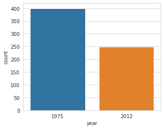

```python
plt.rcParams["figure.figsize"] = [5, 4]
sns.countplot(x="year",data=df);
```

**We can see that 1975 dataset has more samples than 2012 dataset.**

### 2.checking the species count in every year.

```python
df.groupby(["year"])["species"].value_counts()
```

```
year
1975  fortis      313
      scandens     87
2012  scandens    127
      fortis      121
Name: species, dtype: int64
```

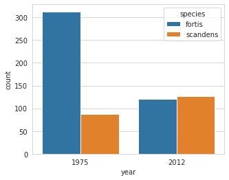

```python
plt.rcParams["figure.figsize"] = [5, 4]
sns.countplot(x="year",data=df, hue="species");
```

**We can see that Fortis specie samples counts is larger in 1975 and scandens specie samples count is larger in 2012. This difference in samples count will be considered as a bias and it may affect our AB test results accuracy.**

### 3.Checking all Finches beak length ECDFs.

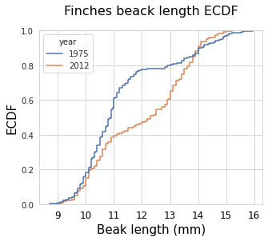

```python
plt.rcParams["figure.figsize"] = [5, 4]
sns.ecdfplot(x="blength",
             data=df,
             hue="year",
             palette="deep")


plt.xlabel("Beak length (mm)", fontsize=15, color="k")
plt.ylabel("ECDF", fontsize=15, color="k")
plt.title("Finches beack length ECDF", fontsize=16, color="k", pad=20)
plt.xticks(fontsize=12, color="k");
```

**We can see that approximate 90% of finches have got taller beak length in 2012.**

### 4.checking Finches beak length distribution.

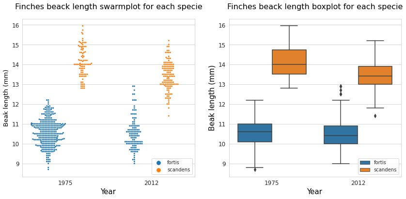

```python
plt.rcParams["figure.figsize"] = [14, 6]
fig, ax = plt.subplots(1,2)



sns.swarmplot(x = "year",
              y="blength",
              data=df,
              hue='species',
              dodge=True,
              size=3,
             ax=ax[0])

ax[0].set_xlabel("Year", fontsize=15, color="k")
ax[0].set_ylabel("Beak length (mm)", fontsize=13, color="k")
ax[0].set_title("Finches beack length swarmplot for each specie", fontsize=16, color="k", pad=20)
ax[0].tick_params(labelsize=12, color="k")
ax[0].legend(loc=4)



sns.boxplot(x = "year",
              y="blength",
              data=df,
              hue='species',
              width=0.8,
              ax=ax[1])


ax[1].set_xlabel("Year", fontsize=15, color="k")
ax[1].set_ylabel("Beak length (mm)", fontsize=15, color="k")
ax[1].set_title("Finches beack length boxplot for each specie", fontsize=16, color="k", pad=20)
ax[1].tick_params(labelsize=12, color="k")
ax[1].legend(loc=4);
```

### 5.Checking Finches beak length ECDFs for each specie separately.

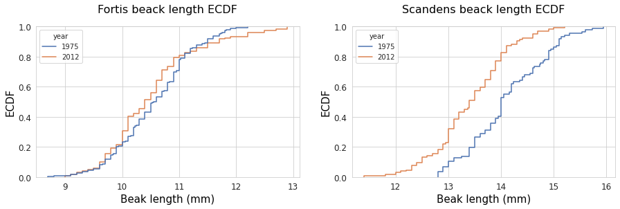

```python
plt.rcParams["figure.figsize"] = [15, 4]
fig, ax = plt.subplots(1,2)


# Fortis beak length ECDFs.

sns.ecdfplot(x="blength",
             data=df[df.species =="fortis"],
             hue="year",
             palette="deep",
             ax = ax[0])



ax[0].set_xlabel("Beak length (mm)", fontsize=15, color="k")
ax[0].set_ylabel("ECDF", fontsize=15, color="k")
ax[0].set_title("Fortis beack length ECDF", fontsize=16, color="k", pad=20)
ax[0].tick_params(labelsize=12, color="k");

# Scandens beak length ECDFs.

sns.ecdfplot(x="blength",
             data=df[df.species =="scandens"],
             hue="year",
             palette="deep",
             ax = ax[1])



ax[1].set_xlabel("Beak length (mm)", fontsize=15, color="k")
ax[1].set_ylabel("ECDF", fontsize=15, color="k")
ax[1].set_title("Scandens beack length ECDF", fontsize=16, color="k", pad=20)
ax[1].tick_params(labelsize=12, color="k");
```

### 6.Checking all Finches beak depth ECDFs.

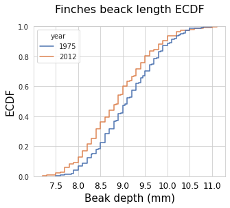

```python
plt.rcParams["figure.figsize"] = [5, 4]
sns.ecdfplot(x="bdepth",
             data=df,
             hue="year",
             palette="deep")


plt.xlabel("Beak depth (mm)", fontsize=15, color="k")
plt.ylabel("ECDF", fontsize=15, color="k")
plt.title("Finches beack length ECDF", fontsize=16, color="k", pad=20)
plt.xticks(fontsize=12, color="k");
```

**We can see that approximate 97% of finches have got shorter beak depth in 2012.**

### 7.Checking Finches beak depth distribution.

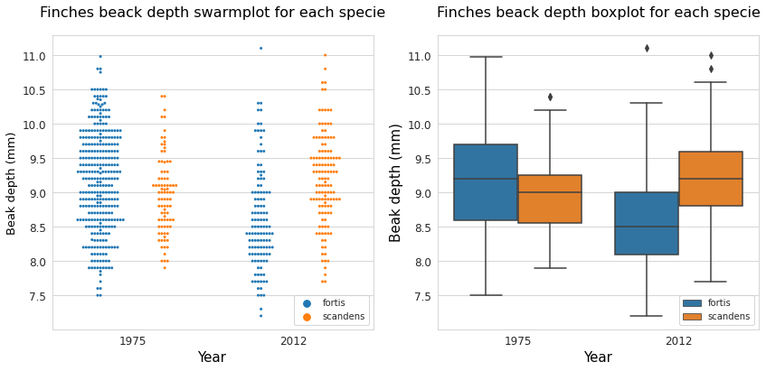

```python
plt.rcParams["figure.figsize"] = [14, 6]
fig, ax = plt.subplots(1,2)



sns.swarmplot(x = "year",
              y="bdepth",
              data=df,
              hue='species',
              dodge=True,
              size=3,
             ax=ax[0])

ax[0].set_xlabel("Year", fontsize=15, color="k")
ax[0].set_ylabel("Beak depth (mm)", fontsize=13, color="k")
ax[0].set_title("Finches beack depth swarmplot for each specie", fontsize=16, color="k", pad=20)
ax[0].tick_params(labelsize=12, color="k")
ax[0].legend(loc=4)



sns.boxplot(x = "year",
              y="bdepth",
              data=df,
              hue='species',
              width=0.8,
              ax=ax[1])


ax[1].set_xlabel("Year", fontsize=15, color="k")
ax[1].set_ylabel("Beak depth (mm)", fontsize=15, color="k")
ax[1].set_title("Finches beack depth boxplot for each specie", fontsize=16, color="k", pad=20)
ax[1].tick_params(labelsize=12, color="k")
ax[1].legend(loc=4);
```

### 8.Checking Finches beak depth ECDFs for each specie separately.

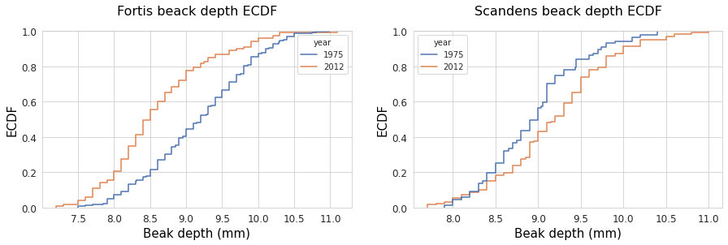

```python
plt.rcParams["figure.figsize"] = [15, 4]
fig, ax = plt.subplots(1,2)


# Fortis beak depth ECDFs.

sns.ecdfplot(x="bdepth",
             data=df[df.species =="fortis"],
             hue="year",
             palette="deep",
             ax = ax[0])



ax[0].set_xlabel("Beak depth (mm)", fontsize=15, color="k")
ax[0].set_ylabel("ECDF", fontsize=15, color="k")
ax[0].set_title("Fortis beack depth ECDF", fontsize=16, color="k", pad=20)
ax[0].tick_params(labelsize=12, color="k");

# Scandens beak depth ECDFs.

sns.ecdfplot(x="bdepth",
             data=df[df.species =="scandens"],
             hue="year",
             palette="deep",
             ax = ax[1])



ax[1].set_xlabel("Beak depth (mm)", fontsize=15, color="k")
ax[1].set_ylabel("ECDF", fontsize=15, color="k")
ax[1].set_title("Scandens beack depth ECDF", fontsize=16, color="k", pad=20)
ax[1].tick_params(labelsize=12, color="k");
```

**We can see that the depth of Fortis specie beak has got shorter in 2012 and the depth of scandens specie beak has got taller in 2012.**

## Descriptive statistics conclutions

### From previous visualisations we can see that conclude that:

**1. 90% of finches have got taller beak length in 2012.**

**2. 97% of finches have got shorter beak depth in 2012.**

**4. The depth of Fortis specie beak has got shorter in 2012 and the depth of scandens specie beak has got taller in 2012.**

- **Note: These conclusions applies only on the data that we already have.**

## AB Testing

> - **Now I'm going to make A/B test to check:**
>   - If finches beaks average length has been evolved from 1975 to 2012 or not.
>   - If finches beaks average depth has been evolved from 1975 to 2012 or not.
> - **Alpha level will be 0.05 so the results will be with 95% confidence.**
> - **I will use bonferroni correction because I'm going to check the results for 2 metrics length and depth so our real Alpha level is (0.05 / 2 = 0.025)**

```python
# Split df into fortis and scandens seperate dataframes.

fortis = df[df.species == "fortis"]
scandens = df[df.species == "scandens"]
```

```python
# Calculating difference of the mean Fortis beak length for both years.¶

fortis_length_diff = fortis[fortis.year ==2012].blength.mean() - fortis[fortis.year ==1975].blength.mean()
fortis_length_diff
```

```
-0.04654239167745011
```

```python
# Calculating difference of the mean Fortis beak depth for both years.

fortis_debth_diff = fortis[fortis.year ==2012].bdepth.mean() - fortis[fortis.year ==1975].bdepth.mean()
fortis_debth_diff
```

```
-0.5644044570010287
```

```python
# Calculating difference of the mean Scandens beak length for both years.¶

scandens_length_diff = scandens[scandens.year ==2012].blength.mean() - scandens[scandens.year ==1975].blength.mean()
scandens_length_diff
```

```
-0.6998959181826354
```

```python
# Calculating difference of the mean Scandens beak depth for both years.

scandens_depth_diff = scandens[scandens.year ==2012].bdepth.mean() - scandens[scandens.year ==1975].bdepth.mean()
scandens_depth_diff
```

```
0.2262204724409429
```

## Problem Statement:

#### 1. Has Finches beaks average length been evolved from 1975 to 2012?

> **Null hypothesis is: Fenchies beak length mean is the same in 1975 and 2012 for both species (Fortis and scandens)**

> **alternative hypothesis is: Fenchies beak length mean is not the same in 1975 and 2012 for both species (Fortis and scandens)**

#### 2. Has Finches beaks average depth been evolved from 1975 to 2012?

> **Null hypothesis is: Fenchies beak depth mean is the same in 1975 and 2012 for both species (Fortis and scandens)**

> **alternative hypothesis is: Fenchies beak depth mean is not the same in 1975 and 2012 for both species (Fortis and scandens)**

\begin{equation} H_{0} : \mu_{2012} - \mu_{1975} = 0 \end{equation}

\begin{equation} H_{1} : \mu_{2012} - \mu_{1975} != 0 \end{equation}

### Bootstrap the data by resampling the dataset with replacement for Fortis length and depth.

```python
fortis_len_diffs = []
fortis_dep_diffs = []

for i in range (10000):
    fortis_boot_sample = fortis.sample(frac=1, replace=True)
    foris_len_mean_75 = fortis_boot_sample[fortis_boot_sample.year==1975].blength.mean()
    foris_len_mean_2012= fortis_boot_sample[fortis_boot_sample.year==2012].blength.mean()
    fortis_len_diff = foris_len_mean_2012 - foris_len_mean_75
    fortis_len_diffs.append(fortis_len_diff)

    foris_dep_mean_75 = fortis_boot_sample[fortis_boot_sample.year==1975].bdepth.mean()
    foris_dep_mean_2012= fortis_boot_sample[fortis_boot_sample.year==2012].bdepth.mean()
    fortis_dep_diff = foris_dep_mean_2012 - foris_dep_mean_75
    fortis_dep_diffs.append(fortis_dep_diff)

fortis_len_diffs = np.array(fortis_len_diffs)
fortis_dep_diffs = np.array(fortis_dep_diffs)
```

```python
# make sampling destribution when null hypothesis is true for fortis length

null_1 = np.random.normal(0,np.std(fortis_len_diffs), 10000)
```

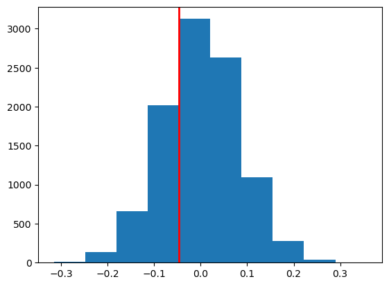

```python
# drawing sampling distrbution using the observed fortis length diff to check p-value
plt.rcdefaults()
plt.hist(null_1)
plt.axvline(fortis_length_diff, lw=2,color="r");
```

```python
# calculate P-value for fortis length difference

fortis_len_p_value = (null_1< fortis_length_diff).mean() + ( null_1> (0 + (0 - fortis_length_diff))).mean()
fortis_len_p_value
```

```
0.5723
```

### Result

> **While P-value is larger than Alpha level we fail to reject the null hypothesis for fortis beak length. Based on this data we have a statistical evidence that the Fortis beak length hasn't been evolved from 1975 to 2012 with 95% confidence.**

```python
# make sampling destribution when null hypothesis is true for fortis depth

null_2 = np.random.normal(0,np.std(fortis_dep_diffs), 10000)
```

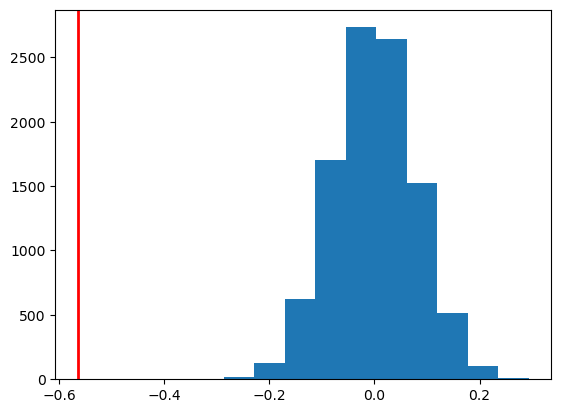

```python
# drawing sampling distrbution using the observed fortis debth diff to check p-value

plt.hist(null_2)
plt.axvline(fortis_debth_diff, lw=2,color="r");
```

```python
# calculate P-value for fortis depth difference

fortis_dep_p_value = (null_2< fortis_debth_diff).mean() + ( null_2> (0 + (0 - fortis_debth_diff))).mean()
fortis_dep_p_value
```

```
0.0
```

### Bootstrap the data by resampling the dataset with replacement for scandens length and depth.

```python
scandens_len_diffs = []
scandens_dep_diffs = []


for i in range (10000):
    scandens_boot_sample = scandens.sample(frac=1, replace=True)
    scandens_len_mean_75 = scandens_boot_sample[scandens_boot_sample.year==1975].blength.mean()
    scandens_len_mean_2012= scandens_boot_sample[scandens_boot_sample.year==2012].blength.mean()
    scandens_len_diff = scandens_len_mean_2012 - scandens_len_mean_75
    scandens_len_diffs.append(scandens_len_diff)

    scandens_dep_mean_75 = scandens_boot_sample[scandens_boot_sample.year==1975].bdepth.mean()
    scandens_dep_mean_2012= scandens_boot_sample[scandens_boot_sample.year==2012].bdepth.mean()
    scandens_dep_diff = scandens_dep_mean_2012 - scandens_dep_mean_75
    scandens_dep_diffs.append(scandens_dep_diff)

scandens_len_diffs = np.array(scandens_len_diffs)
scandens_dep_diffs = np.array(scandens_dep_diffs)
```

```python
# make sampling destribution when null hypothesis is true for scandens length

null_3 = np.random.normal(0,np.std(scandens_len_diffs), 10000)
```

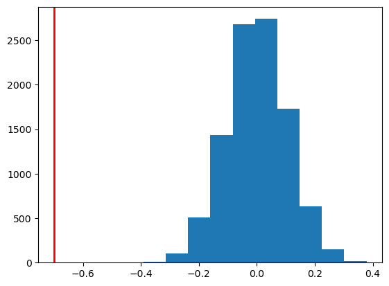

```python
# drawing sampling distrbution using the observed fortis scandens diff to check p-value
plt.rcdefaults()
plt.hist(null_3)
plt.axvline(scandens_length_diff, lw=2,color="r");
```

```python
# calculate P-value for scandens length difference

scandens_len_p_value = (null_3< scandens_length_diff).mean() + ( null_3> (0 + (0 - scandens_length_diff))).mean()
scandens_len_p_value
```

```
0.0
```

### Result

```python
# make sampling destribution when null hypothesis is true for scandens depth

null_4 = np.random.normal(0,np.std(scandens_dep_diffs), 10000)
```

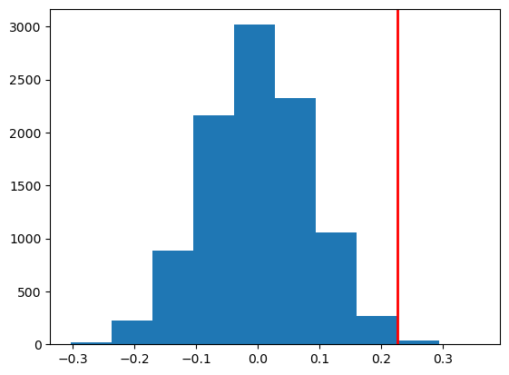

```python
# drawing sampling distrbution using the observed scandens debth diff to check p-value

plt.hist(null_4)
plt.axvline(scandens_depth_diff, lw=2,color="r");
```

```python
# calculate P-value for scandens depth difference

scandens_dep_p_value = (null_4 > scandens_depth_diff).mean() + ( null_4 < 0 - scandens_depth_diff).mean()
scandens_dep_p_value
```

```
0.0069
```

### AB test result

**Based on previous data we have a statistical evidence that:**

> 1. Fortis beak length hasn't been evolved from 1975 to 2012.
> 2. Fortis beak depth has been evolved from 1975 to 2012.
> 3. Scandens beak length has been evolved from 1975 to 2012.
> 4. Scandens beak depth has been evolved from 1975 to 2012.

## Regression Analysis

### 1. Linear regreesion for Fortis beak length and depth.

```python
# checking correlation coefficients for frotis

fortis.corr()
```

|  | band | blength | bdepth | year |
| --- | --- | --- | --- | --- |
| band | 1.000000 | -0.020161 | -0.273211 | 0.925991 |
| blength | -0.020161 | 1.000000 | 0.752965 | -0.029341 |
| bdepth | -0.273211 | 0.752965 | 1.000000 | -0.326970 |
| year | 0.925991 | -0.029341 | -0.326970 | 1.000000 |

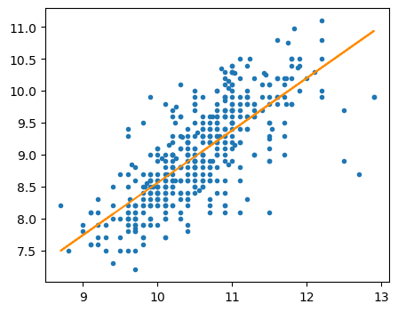

```python
# scatter plot between Fortis finches beak bedoth and length

plt.rcParams["figure.figsize"] = [5, 4]
plt.plot(fortis.blength, fortis.bdepth, linestyle="none", marker=".")

# drwaing the linear line

m, b = np.polyfit(fortis.blength,fortis.bdepth, 1)
plt.plot(fortis.blength, m*fortis.blength+b, color="darkorange");
```

```python
# Linear regreesion model

result = smf.ols("blength ~ bdepth ", data= fortis).fit()
result.summary()
```

OLS Regression Results

| Dep. Variable: | blength | R-squared: | 0.567 |
| --- | --- | --- | --- |
| Model: | OLS | Adj. R-squared: | 0.566 |
| Method: | Least Squares | F-statistic: | 565.6 |
| Date: | Mon, 04 Apr 2022 | Prob (F-statistic): | 1.57e-80 |
| Time: | 13:58:39 | Log-Likelihood: | -286.36 |
| No. Observations: | 434 | AIC: | 576.7 |
| Df Residuals: | 432 | BIC: | 584.9 |
| Df Model: | 1 |  |  |
| Covariance Type: | nonrobust |  |  |

|  | coef | std err | t | P>\|t\| | [0.025 | 0.975] |
| --- | --- | --- | --- | --- | --- | --- |
| Intercept | 4.3148 | 0.263 | 16.395 | 0.000 | 3.798 | 4.832 |
| bdepth | 0.6919 | 0.029 | 23.782 | 0.000 | 0.635 | 0.749 |

| Omnibus: | 74.634 | Durbin-Watson: | 1.812 |
| --- | --- | --- | --- |
| Prob(Omnibus): | 0.000 | Jarque-Bera (JB): | 195.940 |
| Skew: | 0.839 | Prob(JB): | 2.83e-43 |
| Kurtosis: | 5.832 | Cond. No. | 107. |

Notes:  
[1] Standard Errors assume that the covariance matrix of the errors is correctly specified.

**We can see that there is a strong positive correlation between Fortis fenchies beak length and depth.**

**Just 56.7% of variability on length is explained by the depth.**

**for every 1 mm increase in depth we predict length will increase 0.6919 mm.**

**Fortis beak depth is statistically significant in predicting length with 95% confidence**

### 2. Linear regreesion for Scandens beak length and depth.

```python
# checking correlation coefficients for all scandens


scandens.corr()
```

|  | band | blength | bdepth | year |
| --- | --- | --- | --- | --- |
| band | 1.000000 | -0.347167 | 0.189650 | 0.901280 |
| blength | -0.347167 | 1.000000 | 0.407771 | -0.425527 |
| bdepth | 0.189650 | 0.407771 | 1.000000 | 0.174589 |
| year | 0.901280 | -0.425527 | 0.174589 | 1.000000 |

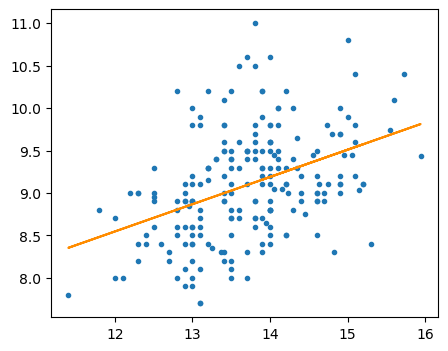

```python
# scatter plot between Scandens finches beak bedoth and length

plt.rcParams["figure.figsize"] = [5, 4]
plt.plot(scandens.blength, scandens.bdepth, linestyle="none", marker=".")

# drwaing the linear line

m, b = np.polyfit(scandens.blength,scandens.bdepth, 1)
plt.plot(scandens.blength, m*scandens.blength+b, color="darkorange");
```

```python
result = smf.ols("blength ~ bdepth ", data= scandens).fit()
result.summary()
```

OLS Regression Results

| Dep. Variable: | blength | R-squared: | 0.166 |
| --- | --- | --- | --- |
| Model: | OLS | Adj. R-squared: | 0.162 |
| Method: | Least Squares | F-statistic: | 42.28 |
| Date: | Mon, 04 Apr 2022 | Prob (F-statistic): | 5.58e-10 |
| Time: | 13:58:40 | Log-Likelihood: | -238.54 |
| No. Observations: | 214 | AIC: | 481.1 |
| Df Residuals: | 212 | BIC: | 487.8 |
| Df Model: | 1 |  |  |
| Covariance Type: | nonrobust |  |  |

|  | coef | std err | t | P>\|t\| | [0.025 | 0.975] |
| --- | --- | --- | --- | --- | --- | --- |
| Intercept | 8.9982 | 0.726 | 12.399 | 0.000 | 7.568 | 10.429 |
| bdepth | 0.5176 | 0.080 | 6.502 | 0.000 | 0.361 | 0.675 |

| Omnibus: | 2.492 | Durbin-Watson: | 1.362 |
| --- | --- | --- | --- |
| Prob(Omnibus): | 0.288 | Jarque-Bera (JB): | 2.385 |
| Skew: | 0.191 | Prob(JB): | 0.303 |
| Kurtosis: | 2.652 | Cond. No. | 132. |

Notes:  
[1] Standard Errors assume that the covariance matrix of the errors is correctly specified.

**We can see that there is a weak positive correlation between Scandens beak length and depth.**

**Just 16.6% of variability on length is explained by the depth so this model isn't fit very well.**

**For every 1 mm increase in depth we predict length will increase 0.5176 mm.**

**Scandens beak depth is statistically significant in predicting length with 95% confidence**

## Conclusions

### A. Descriptive statistics conclutions:

> **1. 90% of finches have got taller beak length in 2012.**

> **2. 97% of finches have got shorter beak depth in 2012.**

> **4. The depth of Fortis specie beak has got shorter in 2012 and the depth of scandens specie beak has got taller in 2012.**
- **Note: These conclusions applies only on the data that we already have.**

### B. AB Test conclutions:

> **1. We have a statistical evidence that the Fortis beak length hasn't been evolved from 1975 to 2012 with 95% confidence**

> **2.We have a statistical evidence that the Fortis beak depth has been evolved from 1975 to 2012 with 95% confidence.**

> **3. We have a statistical evidence that the Scandens beak length has been evolved from 1975 to 2012 with 95% confidence.**

> **4. We have a statistical evidence that the The scandens beak depth has been evolved from 1975 to 2012 with 95% confidence.**

### C. Regression analysis conclutions:

> **1. There is a weak positive correlation between Scandens beak length and depth.**

> **1. There is a strong positive correlation between Fortis fenchies beak length and depth.**

> **3. For every 1 mm increase in Fortis fenchies beak depth we predict that their beak length will increase with 0.6919 mm.**

> **4. For every 1 mm increase in Scandens fenchies beak depth we predict that their beak length will increase with 0.5176 mm.**

> **5. Scandens beak depth is statistically significant in predicting their beak length with 95% confidence**

> **6. Fortis beak depth is statistically significant in predicting their beak length with 95% confidence.**

## Limitations

**1. 1975 dataset has more samples than 2012 dataset.**

**2. Fortis specie samples counts is larger in 1975 and scandens specie samples count is larger in 2012. This difference in samples count will be considered as a bias and it may affect our AB test results accuracy.**